# Analyse en Composantes Principales

Jeu de données data_bwd_fwd_2019

Ce jeu de données contient 24 individus et 34 variables.

### 1. Observation d’individus extrêmes

L’analyse des graphes détecte un individu singulier qui influence très fortement les résultats observés. On soulignera dans un premier temps le caractère extrême de cet individu avant de le retirer pour procéder à la suite de l’analyse. En observant le graphe, on peut noter qu’un individu est très particulier et contribue énormément à la construction du plan. Sa contribution à la construction du plan est de **32.5%**.

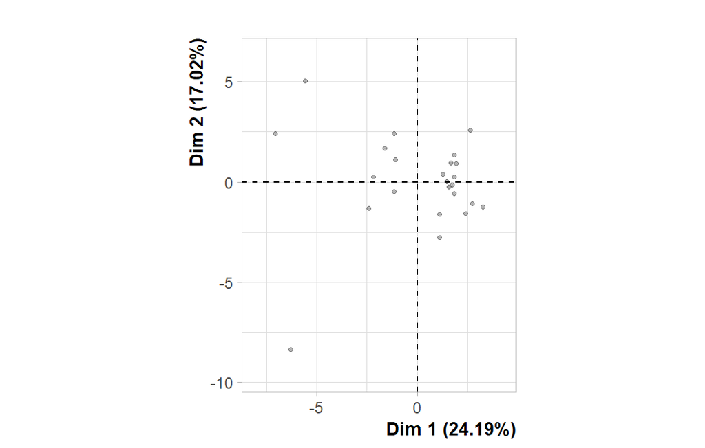

**Figure 1.1 - Graphe des individus (ACP) avant correction.** *Mise en évidence d’un individu singulier.*

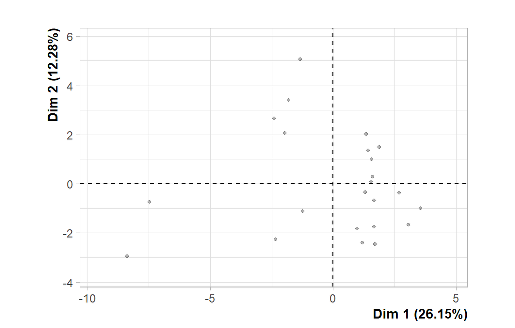

**Figure 1.2 - Graphe des individus (ACP) après correction.** *Mise en évidence d’un individu singulier.*

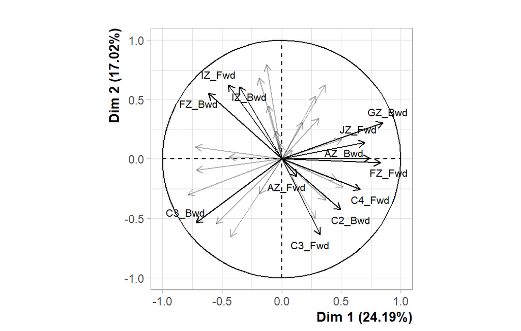

**Figure 1.3 - Graphe des variables (ACP) avant correction** *Les variables libellées sont celles les mieux représentées sur le plan.*

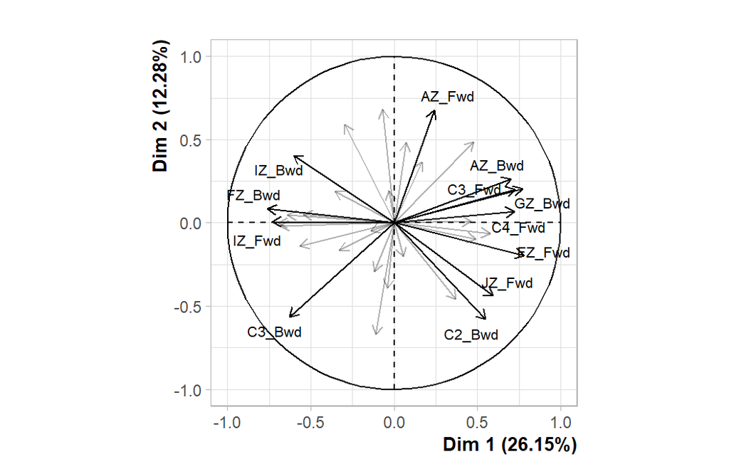

**Figure 1.3 - Graphe des variables (ACP) après correction**

**L’individu 19** :

- prend de très fortes valeurs pour le(s) variable(s) : *C3_Bwd*, *C5_Bwd*, *C4_Bwd*, *DE_Fwd* et *C3_Fwd* (de la plus extrême à la moins extrême).
- prend de très faibles valeurs pour les variables : *KZ_Fwd*, *C1_Fwd*, *GZ_Bwd*, *MN_Bwd*, *DE_Bwd*, *RU_Fwd* et *JZ_Fwd* (de la plus extrême à la moins extrême).

Après avoir éliminé cet individu singulier, on peut explorer le reste des individus par une seconde analyse.

### 2. Distribution de l’inertie

L’inertie des axes factoriels indique d’une part si les variables sont structurées et suggère d’autre part le nombre judicieux de composantes principales à étudier.

Les 2 premiers axes de l’ analyse expriment **38.43%** de l’inertie totale du jeu de données ; cela signifie que 38.43% de la variabilité totale du nuage des individus (ou des variables) est représentée dans ce plan. C’est un pourcentage relativement moyen, et le premier plan représente donc seulement une part de la variabilité contenue dans l’ensemble du jeu de données actif. Cette valeur est supérieure à la valeur référence de **25.85%**, la variabilité expliquée par ce plan est donc significative (cette intertie de référence est le quantile 0.95-quantile de la distribution des pourcentages d’inertie obtenue en simulant 4350 jeux de données aléatoires de dimensions comparables sur la base d’une distribution normale).

Du fait de ces observations, il serait alors probablement nécessaire de considérer également les dimensions supérieures ou égales à la troisième dans l’analyse.

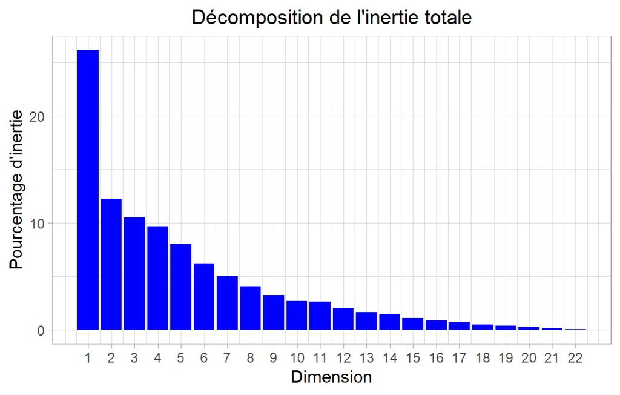

**Figure 2 - Décomposition de l’inertie totale**

Une estimation du nombre pertinent d’axes à interpréter suggère de restreindre l’analyse à la description des 5 premiers axes. Ces composantes révèlent un taux d’inertie supérieur à celle du quantile 0.95-quantile de distributions aléatoires (66.68% contre 52.54%). Cette observation suggère que seuls ces axes sont porteurs d’une véritable information. En conséquence, la description de l’analyse sera restreinte à ces seuls axes.

### 3. Description du plan 1:2

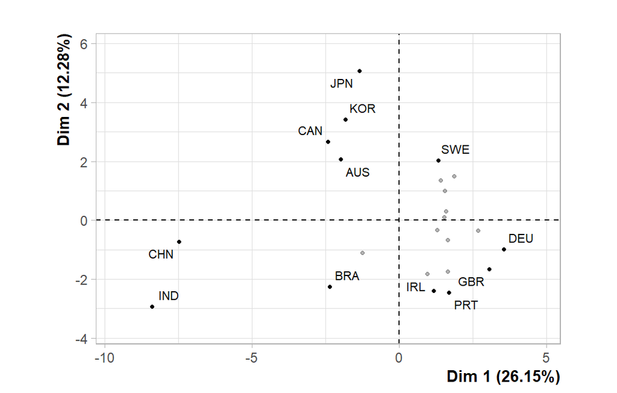

**Figure 3.1 - Graphe des individus (ACP)** *Les individus libellés sont ceux ayant la plus grande contribution à la construction du plan.*

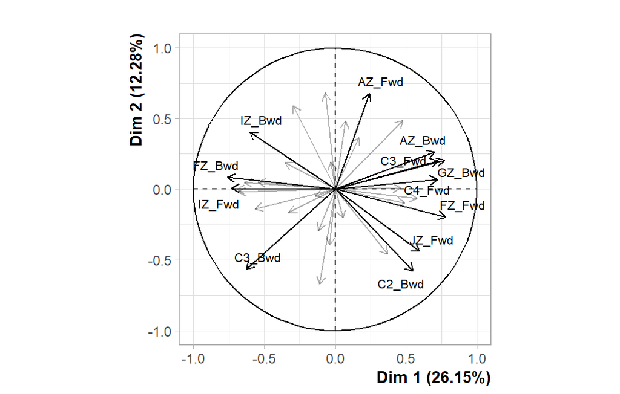

**Figure 3.2 - Graphe des variables (ACP)** *Les variables libellées sont celles les mieux représentées sur le plan.*

Le groupe auquel les individus *IND* et *CHN* appartiennent (caractérisés par une coordonnées négative sur l’axe) partage :

- de fortes valeurs pour les variables *IZ_Fwd*, *MN_Bwd*, *FZ_Bwd*, *GZ_Fwd*, *C3_Bwd*, *C2_Fwd*, *IZ_Bwd* et *RU_Fwd* (de la plus extrême à la moins extrême).
- de faibles valeurs pour les variables *C3_Fwd*, *GZ_Bwd*, *AZ_Bwd*, *C4_Fwd*, *C5_Fwd*, *FZ_Fwd*, *LZ_Fwd* et *C1_Bwd* (de la plus extrême à la moins extrême).

Le groupe auquel les individus *JPN*, *KOR*, *CAN* et *AUS* appartiennent (caractérisés par une coordonnée positive sur l’axe) partage :

- de fortes valeurs pour les variables *OQ_Fwd* et *RU_Bwd* (de la plus extrême à la moins extrême).
- de faibles valeurs pour les variables *HZ_Fwd*, *JZ_Fwd* et *C2_Bwd* (de la plus extrême à la moins extrême).

### 4. Description du plan 3:4

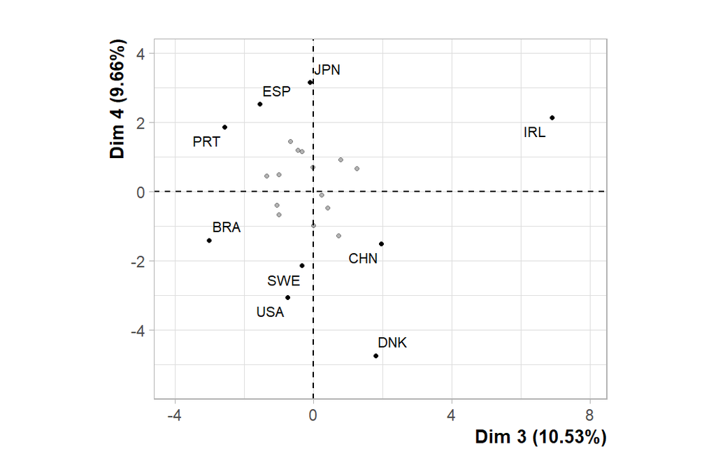

**Figure 4.1 - Graphe des individus (ACP)** *Les individus libellés sont ceux ayant la plus grande contribution à la construction du plan.*

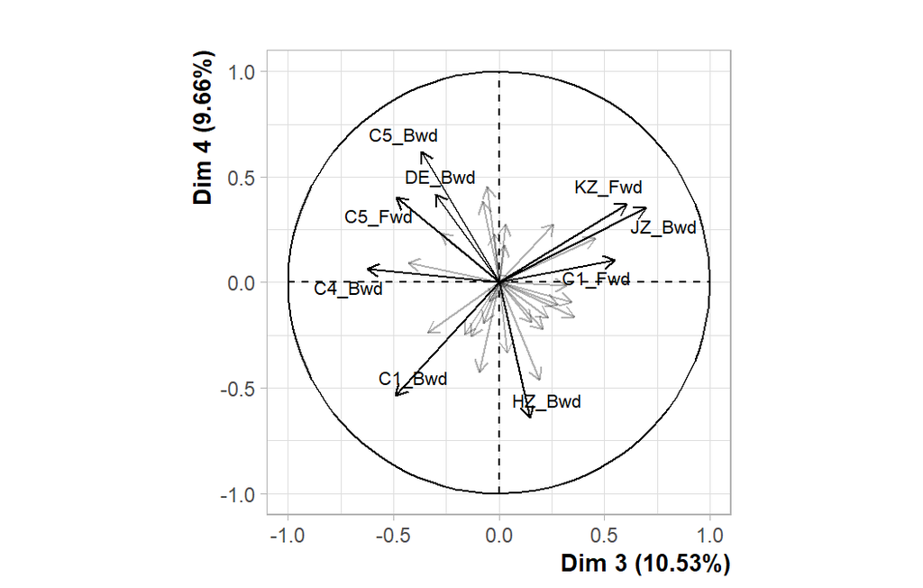

**Figure 4.2 - Graphe des variables (ACP)** *Les variables libellées sont celles les mieux représentées sur le plan.*

Le groupe auquel l’individu *IRL* appartient (caractérisés par une coordonnée positive sur l’axe) partage :

- de fortes valeurs pour les variables *JZ_Bwd*, *KZ_Fwd*, *KZ_Bwd* et *MN_Fwd* (de la plus extrême à la moins extrême).
- de faibles valeurs pour les variables *C2_Fwd*, *C4_Bwd*, *IZ_Bwd* et *C5_Fwd* (de la plus extrême à la moins extrême).

Le groupe auquel les individus *DNK*, *USA*, *SWE* et *CHN* appartiennent (caractérisés par une coordonnées négative sur l’axe) partage :

- de fortes valeurs pour la variable *LZ_Bwd*.
- de faibles valeurs pour les variables *KZ_Bwd*, *C5_Bwd* et *MN_Fwd* (de la plus extrême à la moins extrême).

### 5. Description de la dimension 5

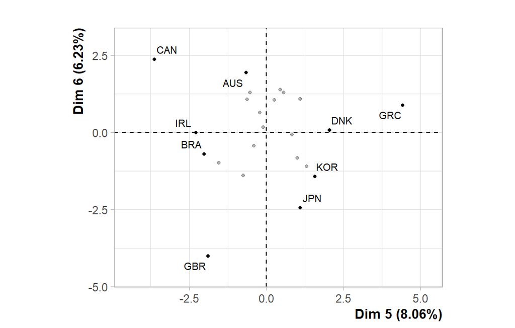

**Figure 5.1 - Graphe des individus (ACP)** *Les individus libellés sont ceux ayant la plus grande contribution à la construction du plan.*

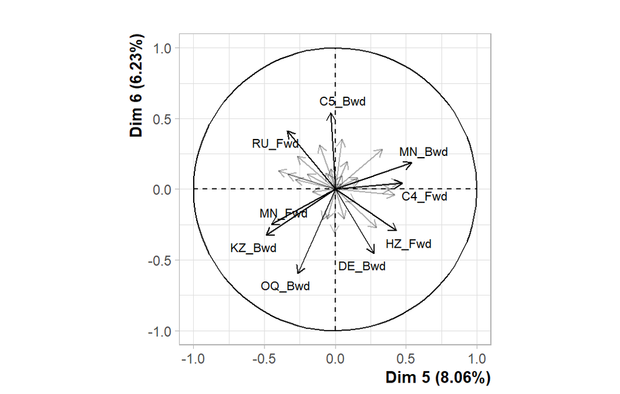

**Figure 5.2 - Graphe des variables (ACP)** *Les variables libellées sont celles les mieux représentées sur le plan.*

Le groupe auquel les individus *GRC*, *KOR*, *JPN* et *DNK* appartiennent (caractérisés par une coordonnée positive sur l’axe) partage :

Le groupe auquel les individus *GBR*, *BRA* et *IRL* appartiennent (caractérisés par une coordonnées négative sur l’axe) partage :

- de fortes valeurs pour les variables *MN_Fwd* et *KZ_Bwd* (de la plus extrême à la moins extrême).
- de faibles valeurs pour les variables *C4_Fwd* et *C1_Fwd* (de la plus extrême à la moins extrême).